# analyze_1.1.3.15

This notebook is intended to explore the 1.1.3.15 data and figure out the storyline.  
Copyright (C) 2019 Martin Engqvist Lab  
This program is free software: you can redistribute it and/or modify  
it under the terms of the GNU General Public License as published by  
the Free Software Foundation, either version 3 of the License, or  
(at your option) any later version.  
This program is distributed in the hope that it will be useful,  
but WITHOUT ANY WARRANTY; without even the implied warranty of  
MERCHANTABILITY or FITNESS FOR A PARTICULAR PURPOSE. See the  
GNU General Public License for more details.  
You should have received a copy of the GNU General Public License  
along with this program. If not, see http://www.gnu.org/licenses/.

## TODO

- Generate tables for supplemental data
- Re-run scripts

```python
import os
from dotenv import load_dotenv, find_dotenv
from os.path import join, dirname, basename, exists, isdir

### Load environmental variables from the project root directory ###
# find .env automagically by walking up directories until it's found
dotenv_path = find_dotenv()

# load up the entries as environment variables
load_dotenv(dotenv_path)

# now you can get the variables using their names

# Check whether a network drive has been specified
DATABASE = os.environ.get("NETWORK_URL")
if DATABASE == 'None':
    pass
else:
    pass
    #mount network drive here

# set up directory paths
CURRENT_DIR = os.getcwd()
PROJ = dirname(dotenv_path) # project root directory

DATA = join(PROJ, 'data') #data directory
RAW_EXTERNAL = join(DATA, 'raw_external') # external data raw directory
RAW_INTERNAL = join(DATA, 'raw_internal') # internal data raw directory
INTERMEDIATE = join(DATA, 'intermediate') # intermediate data directory
FINAL = join(DATA, 'final') # final data directory

RESULTS = join(PROJ, 'results') # output directory
FIGURES = join(RESULTS, 'figures') # figure output directory
PICTURES = join(RESULTS, 'pictures') # picture output directory


# make folders specific for certain data
folder_name = 'similarity_data'
if folder_name != '':
#     #make folders if they don't exist
#     if not exists(join(RAW_EXTERNAL, folder_name)):
#         os.makedirs(join(RAW_EXTERNAL, folder_name))

#     if not exists(join(INTERMEDIATE, folder_name)):
#         os.makedirs(join(INTERMEDIATE, folder_name))

    if not exists(join(FINAL, folder_name)):
        os.makedirs(join(FINAL, folder_name))

print('Standard variables loaded, you are good to go!')
```

```
Standard variables loaded, you are good to go!
```

```python
import json
import re
import random
import pandas as pd
import numpy as np

import matplotlib.pyplot as plt
from matplotlib.patches import Rectangle
import seaborn as sns; sns.set(style="ticks", color_codes=True)

import sklearn
from sklearn.decomposition import PCA
from sklearn.manifold import MDS

from colcol import scales
import string

# import tsne
import sys; sys.path.append('/home/localadmin/github/FIt-SNE')
from fast_tsne import fast_tsne
```

#### Load the 1.1.3.15 sequences encoded using UniRep embeddings

```python
# load data and drop duplicates
filepath = join(INTERMEDIATE, '1.1.3.n_test_data', '1_1_3__BRENDA_sequences_filtered_unirep.csv')
unirep = pd.read_csv(filepath, sep=',')

# replace the first column with identifiers
unirep['Unnamed: 0'] = [i.split(';')[0] for i in unirep['Unnamed: 0']]


# re-name column
unirep = unirep.rename(columns={'Unnamed: 0':'uid'}).drop_duplicates()

# load uid to ec mapping and merge with property data
filepath = join(FINAL, 'BRENDA', 'ec_uid_org_from_fasta.tsv')
uid_ec = pd.read_csv(filepath, sep='\t').drop_duplicates()



# merge with ec data
unirep_merged = unirep.merge(uid_ec, on='uid')

# keep only ec 1.1.3.15
df_unirep = unirep_merged[unirep_merged.ec=='1.1.3.15'].drop('ec', axis=1)

display(df_unirep.head())
display(df_unirep.tail())
display(df_unirep.shape)
```

|  | uid | av_1 | av_2 | av_3 | av_4 | av_5 | av_6 | av_7 | av_8 | av_9 | ... | fc_1891 | fc_1892 | fc_1893 | fc_1894 | fc_1895 | fc_1896 | fc_1897 | fc_1898 | fc_1899 | fc_1900 |
| --- | --- | --- | --- | --- | --- | --- | --- | --- | --- | --- | --- | --- | --- | --- | --- | --- | --- | --- | --- | --- | --- |
| 33 | Q9LRS0 | 0.015368 | 0.207102 | 0.076687 | -0.040839 | -0.116888 | 0.069290 | 0.011434 | -0.046359 | -0.004900 | ... | 0.314290 | 0.790594 | -0.073425 | 0.092050 | -2.026679 | -0.509705 | 0.087245 | -1.506297 | 0.134522 | 0.133363 |
| 34 | Q9NYQ3 | 0.008693 | 0.174844 | 0.069413 | -0.042212 | -0.134430 | 0.074950 | 0.001461 | -0.043215 | -0.005424 | ... | 0.089248 | -0.263056 | -0.042254 | 1.496964 | -5.197632 | -0.705789 | 0.733266 | -2.503108 | 0.237560 | 0.250488 |
| 35 | P37339 | 0.024516 | 0.012727 | 0.070110 | -0.008737 | -0.356430 | 0.079727 | -0.072076 | 0.021245 | -0.004387 | ... | 0.002008 | -0.151272 | -0.355467 | 0.982859 | -12.764019 | 0.079447 | 0.277420 | -0.994416 | 0.123665 | 4.128018 |
| 36 | Q24JJ8 | 0.011160 | 0.157242 | 0.094497 | -0.049337 | -0.101914 | 0.079308 | 0.020020 | -0.047959 | -0.003755 | ... | 0.467036 | 0.284700 | -0.034987 | 0.619065 | 0.641811 | -1.148384 | -0.318679 | -2.219294 | 0.175719 | 0.342886 |
| 37 | B8AUI3 | 0.015618 | 0.195817 | 0.077877 | -0.038937 | -0.114840 | 0.062852 | 0.023076 | -0.044319 | -0.004918 | ... | 0.174403 | -0.260183 | -0.017469 | 0.329009 | -3.487079 | -0.563793 | -1.393169 | -1.276244 | 0.272283 | -0.236024 |

5 rows × 5701 columns

|  | uid | av_1 | av_2 | av_3 | av_4 | av_5 | av_6 | av_7 | av_8 | av_9 | ... | fc_1891 | fc_1892 | fc_1893 | fc_1894 | fc_1895 | fc_1896 | fc_1897 | fc_1898 | fc_1899 | fc_1900 |
| --- | --- | --- | --- | --- | --- | --- | --- | --- | --- | --- | --- | --- | --- | --- | --- | --- | --- | --- | --- | --- | --- |
| 1439 | D5MNA0 | 0.005720 | 0.144893 | 0.087827 | -0.028350 | -0.115191 | 0.140921 | 0.024286 | -0.015941 | -0.004543 | ... | -0.699620 | -0.425998 | -0.048586 | 0.894642 | -5.685828 | 1.162903 | 0.466842 | 1.646118 | -2.875165 | -1.577959 |
| 1440 | A9QH69 | 0.010057 | 0.200460 | 0.092278 | -0.044776 | -0.151360 | 0.093140 | -0.047560 | -0.036216 | -0.004398 | ... | 0.175783 | -0.203717 | -0.694060 | 1.253930 | -1.231092 | -1.365787 | 0.013075 | -2.970456 | -0.251001 | -0.182736 |
| 1441 | A9QH71 | 0.009455 | 0.219847 | 0.103803 | -0.050824 | -0.151323 | 0.089220 | -0.036848 | -0.034098 | -0.005225 | ... | -0.157484 | 0.843793 | -1.082651 | 0.641018 | 0.119636 | -1.160653 | 0.113823 | -2.279760 | -1.942496 | -0.435206 |
| 1442 | Q9CG58 | 0.013375 | 0.151428 | 0.068151 | -0.040234 | -0.185927 | 0.091063 | -0.046391 | -0.040538 | -0.005390 | ... | 0.472637 | 0.943567 | -0.594633 | 0.482976 | -4.980826 | -1.161524 | 0.885641 | -1.171051 | -0.503931 | -0.224056 |
| 1443 | Q5SM78 | 0.006447 | 0.011494 | 0.019374 | -0.024663 | 0.129485 | 0.051069 | -0.339259 | -0.028680 | -0.008576 | ... | -0.817560 | -0.619732 | -3.377045 | 1.294015 | -3.438791 | -0.503038 | 1.146056 | 2.180835 | 3.405268 | -0.993080 |

5 rows × 5701 columns

```
(1411, 5701)
```

#### Load the enzyme property data

```python
# load enzyme property information
filepath = join(FINAL, 'BRENDA', '1-1-3-n_identifier_info.tsv')
uid_property = pd.read_csv(filepath, sep='\t').drop_duplicates()

uid_property.drop(['lineage_identifiers', 'lineage_ranks', 'lineage_names'],
                  inplace=True,
                 axis=1)

# load uid to ec mapping and merge with property data
filepath = join(FINAL, 'BRENDA', 'ec_uid_org_from_fasta.tsv')
uid_ec = pd.read_csv(filepath, sep='\t').drop_duplicates()

# merge with the ec mapping
uid_data = uid_property.merge(uid_ec, on=['uid'])

# sort in the same order as the unirep data
uid_data['sort_cat'] = pd.Categorical(uid_data['uid'],
                                          categories=df_unirep.uid,
                                          ordered=True)
uid_data.sort_values('sort_cat', inplace=True)
uid_data.reset_index(inplace=True)

# drop columns that aren't needed
uid_data = uid_data.drop(['sort_cat', 'index'], axis=1)

display(uid_data.head())
display(uid_data.tail())
```

|  | uid | taxid | organism | superkingdom | ph | temperature | pfam | ec |
| --- | --- | --- | --- | --- | --- | --- | --- | --- |
| 0 | Q9LRS0 | 3702.0 | Arabidopsis thaliana | Eukaryota | NaN | NaN | NaN | 1.1.3.15 |
| 1 | Q9NYQ3 | 9606.0 | Homo sapiens | Eukaryota | NaN | NaN | NaN | 1.1.3.15 |
| 2 | P37339 | 83333.0 | Escherichia coli | Bacteria | 7.01 | 36.0 | NaN | 1.1.3.15 |
| 3 | Q24JJ8 | 3702.0 | Arabidopsis thaliana | Eukaryota | NaN | NaN | NaN | 1.1.3.15 |
| 4 | B8AUI3 | 39946.0 | Oryza sativa | Eukaryota | NaN | NaN | NaN | 1.1.3.15 |

|  | uid | taxid | organism | superkingdom | ph | temperature | pfam | ec |
| --- | --- | --- | --- | --- | --- | --- | --- | --- |
| 2050 | B9REU4 | 3988.0 | Ricinus communis | Eukaryota | NaN | NaN | PF07250, PF09118 | 1.1.3.9 |
| 2051 | B9RYU4 | 3988.0 | Ricinus communis | Eukaryota | NaN | NaN | PF07250, PF09118 | 1.1.3.9 |
| 2052 | B9R845 | 3988.0 | Ricinus communis | Eukaryota | NaN | NaN | PF07250, PF09118 | 1.1.3.9 |
| 2053 | M5CRB8 | 1118156.0 | Stenotrophomonas maltophilia | Bacteria | 7.27 | 30.0 | NaN | 1.1.3.9 |
| 2054 | B8MB95 | 441959.0 | Talaromyces stipitatus | Eukaryota | 5.60 | 25.0 | PF09118 | 1.1.3.9 |

#### Load experimental data and combine with enzyme property data

```python
filepath = join(FINAL, 'experiments')

batch1 = pd.read_csv(join(filepath, '1-1-3-n_batch1_summary.tsv'), sep='\t')
batch2 = pd.read_csv(join(filepath, '1-1-3-n_batch2_summary.tsv'), sep='\t')

# rename the column for the identifier
batch1.rename(columns={'node':'uid'}, inplace=True)
batch2.rename(columns={'name':'uid'}, inplace=True)

# add info on which batch it is
batch1['batch'] = 'first'
batch2['batch'] = 'second'

# check that there are no duplicates
for uid in batch1.uid.values:
    if uid in batch2.uid.values:
        print('Bad overlap, uid %s exists in both datasets' % uid)


# combine them
both_batches = batch1.append(batch2).drop_duplicates()

# use True and False instead of Yes and No
both_batches = both_batches.replace(True, 'Yes', regex=True)
both_batches = both_batches.replace(False, 'No', regex=True)

# drop unnessecary columns
both_batches = both_batches[(both_batches['synthesized'] == 'Yes') |
                            (both_batches['synthesized'] == 'No')]
both_batches.drop(['rep1_soluble',
                   'rep1_active',
                   'rep2_soluble',
                   'rep2_active',
                   'rep3_soluble',
                   'rep3_active'], axis=1, inplace=True)

display(both_batches.head())


# now merge with the other data
uid_data = uid_data.merge(both_batches, on='uid', how='left')

# replace empty strings with nans
uid_data = uid_data.replace('', np.nan, regex=True)

display(uid_data.head())
display(uid_data.tail())
```

|  | uid | synthesized | substrate_available | total_soluble | total_active | batch |
| --- | --- | --- | --- | --- | --- | --- |
| 0 | A0A009NBJ7 | Yes | Yes | No | NaN | first |
| 1 | A0A011R8E6 | Yes | Yes | No | NaN | first |
| 2 | A0A017H745 | Yes | Yes | No | NaN | first |
| 3 | A0A024H7W1 | Yes | Yes | Yes | Yes | first |
| 4 | A0A073CBY9 | Yes | Yes | Yes | No | first |

|  | uid | taxid | organism | superkingdom | ph | temperature | pfam | ec | synthesized | substrate_available | total_soluble | total_active | batch |
| --- | --- | --- | --- | --- | --- | --- | --- | --- | --- | --- | --- | --- | --- |
| 0 | Q9LRS0 | 3702.0 | Arabidopsis thaliana | Eukaryota | NaN | NaN | NaN | 1.1.3.15 | NaN | NaN | NaN | NaN | NaN |
| 1 | Q9NYQ3 | 9606.0 | Homo sapiens | Eukaryota | NaN | NaN | NaN | 1.1.3.15 | NaN | NaN | NaN | NaN | NaN |
| 2 | P37339 | 83333.0 | Escherichia coli | Bacteria | 7.01 | 36.0 | NaN | 1.1.3.15 | NaN | NaN | NaN | NaN | NaN |
| 3 | Q24JJ8 | 3702.0 | Arabidopsis thaliana | Eukaryota | NaN | NaN | NaN | 1.1.3.15 | NaN | NaN | NaN | NaN | NaN |
| 4 | B8AUI3 | 39946.0 | Oryza sativa | Eukaryota | NaN | NaN | NaN | 1.1.3.15 | NaN | NaN | NaN | NaN | NaN |

|  | uid | taxid | organism | superkingdom | ph | temperature | pfam | ec | synthesized | substrate_available | total_soluble | total_active | batch |
| --- | --- | --- | --- | --- | --- | --- | --- | --- | --- | --- | --- | --- | --- |
| 2050 | B9REU4 | 3988.0 | Ricinus communis | Eukaryota | NaN | NaN | PF07250, PF09118 | 1.1.3.9 | NaN | NaN | NaN | NaN | NaN |
| 2051 | B9RYU4 | 3988.0 | Ricinus communis | Eukaryota | NaN | NaN | PF07250, PF09118 | 1.1.3.9 | Yes | Yes | No | NaN | second |
| 2052 | B9R845 | 3988.0 | Ricinus communis | Eukaryota | NaN | NaN | PF07250, PF09118 | 1.1.3.9 | Yes | Yes | No | NaN | first |
| 2053 | M5CRB8 | 1118156.0 | Stenotrophomonas maltophilia | Bacteria | 7.27 | 30.0 | NaN | 1.1.3.9 | Yes | Yes | No | NaN | first |
| 2054 | B8MB95 | 441959.0 | Talaromyces stipitatus | Eukaryota | 5.60 | 25.0 | PF09118 | 1.1.3.9 | Yes | Yes | No | NaN | second |

#### Load data on the substrate-level

```python
# load up the data from both batches
data1 = pd.read_csv(join(FINAL, 'experiments', '1.1.3.15_detailed_batch1.csv'),
                    sep=';',
                    index_col=None)
data2 = pd.read_csv(join(FINAL, 'experiments', '1.1.3.15_detailed_batch2.csv'),
                    sep=';',
                    index_col=None)
data = data1.append(data2)

# change True to Yes and False to No
data.replace(True, 'Yes', regex=False, inplace=True)
data.replace(False, 'No', regex=False, inplace=True)

# re-name protein column
data.rename(columns={'protein':'uid'}, inplace=True)

# combine with all the other data from 1.1.3.15
uid_data_subset = uid_data[uid_data['ec']=='1.1.3.15']
prop_data = uid_data_subset.merge(data,
                     on='uid',
                     how='left')

display(prop_data.head())
display(prop_data.tail())
display(prop_data.describe())
display(prop_data.shape)
```

|  | uid | taxid | organism | superkingdom | ph | temperature | pfam | ec | synthesized | substrate_available | total_soluble | total_active | batch | glycolate | lactate | 2-hydroxyglutarate | 2-hydroxyoctanoate | 2-hydroxystearate | mandelate |
| --- | --- | --- | --- | --- | --- | --- | --- | --- | --- | --- | --- | --- | --- | --- | --- | --- | --- | --- | --- |
| 0 | Q9LRS0 | 3702.0 | Arabidopsis thaliana | Eukaryota | NaN | NaN | NaN | 1.1.3.15 | NaN | NaN | NaN | NaN | NaN | NaN | NaN | NaN | NaN | NaN | NaN |
| 1 | Q9NYQ3 | 9606.0 | Homo sapiens | Eukaryota | NaN | NaN | NaN | 1.1.3.15 | NaN | NaN | NaN | NaN | NaN | NaN | NaN | NaN | NaN | NaN | NaN |
| 2 | P37339 | 83333.0 | Escherichia coli | Bacteria | 7.01 | 36.0 | NaN | 1.1.3.15 | NaN | NaN | NaN | NaN | NaN | NaN | NaN | NaN | NaN | NaN | NaN |
| 3 | Q24JJ8 | 3702.0 | Arabidopsis thaliana | Eukaryota | NaN | NaN | NaN | 1.1.3.15 | NaN | NaN | NaN | NaN | NaN | NaN | NaN | NaN | NaN | NaN | NaN |
| 4 | B8AUI3 | 39946.0 | Oryza sativa | Eukaryota | NaN | NaN | NaN | 1.1.3.15 | NaN | NaN | NaN | NaN | NaN | NaN | NaN | NaN | NaN | NaN | NaN |

|  | uid | taxid | organism | superkingdom | ph | temperature | pfam | ec | synthesized | substrate_available | total_soluble | total_active | batch | glycolate | lactate | 2-hydroxyglutarate | 2-hydroxyoctanoate | 2-hydroxystearate | mandelate |
| --- | --- | --- | --- | --- | --- | --- | --- | --- | --- | --- | --- | --- | --- | --- | --- | --- | --- | --- | --- |
| 1406 | D5MNA0 | 671143.0 | Candidatus methylomirabilis | Bacteria | NaN | NaN | NaN | 1.1.3.15 | NaN | NaN | NaN | NaN | NaN | NaN | NaN | NaN | NaN | NaN | NaN |
| 1407 | A9QH69 | 1346.0 | Streptococcus iniae | Bacteria | 7.10 | 37.0 | NaN | 1.1.3.15 | Yes | Yes | Yes | Yes | first | Yes | Yes | No | Yes | Yes | No |
| 1408 | A9QH71 | 1346.0 | Streptococcus iniae | Bacteria | 7.10 | 37.0 | NaN | 1.1.3.15 | NaN | NaN | NaN | NaN | NaN | NaN | NaN | NaN | NaN | NaN | NaN |
| 1409 | Q9CG58 | 272623.0 | Lactococcus lactis | Bacteria | 7.04 | 31.0 | NaN | 1.1.3.15 | NaN | NaN | NaN | NaN | NaN | NaN | NaN | NaN | NaN | NaN | NaN |
| 1410 | Q5SM78 | 300852.0 | Thermus thermophilus | Bacteria | 7.18 | 71.0 | NaN | 1.1.3.15 | NaN | NaN | NaN | NaN | NaN | NaN | NaN | NaN | NaN | NaN | NaN |

|  | taxid | ph | temperature |
| --- | --- | --- | --- |
| count | 1.258000e+03 | 811.000000 | 1036.000000 |
| mean | 6.496091e+05 | 7.024032 | 33.610039 |
| std | 5.306286e+05 | 0.445190 | 7.201882 |
| min | 1.950000e+02 | 1.500000 | 10.000000 |
| 25% | 1.020845e+05 | 7.000000 | 29.000000 |
| 50% | 5.666790e+05 | 7.010000 | 36.000000 |
| 75% | 1.126095e+06 | 7.120000 | 36.000000 |
| max | 1.835254e+06 | 9.000000 | 90.000000 |

```
(1411, 19)
```

#### Add information regarding which sequences are marked as characterized in BRENDA

```python
in_brenda = ['Q9NYQ2',
 'Q9CG58',
 'Q9UJM8',
 'Q10CE4',
 'Q07523',
 'A9QH69',
 'Q9NYQ3',
 'Q9LRR9',
 'Q9LJH5',
 'A9QH71',
 'Q5SM78',
 'Q56ZN0',
 'Q24JJ8',
 'P05414',
 'B7FUG8',
 'K2V617',
 'Q19U05',
 'Q9WU19'] # BRENDA version 2019.1, all tables


active = []
for uid in in_brenda:
    active.append('Yes')

brenda_df = pd.DataFrame({'uid':in_brenda, 'in_brenda':active})


# merge with data frame
prop_data = prop_data.merge(brenda_df, on=['uid'], how='left')


# replace nans
prop_data.in_brenda = prop_data.in_brenda.replace(np.nan, 'No', regex=False)

display(prop_data.head())
display(prop_data.tail())
```

|  | uid | taxid | organism | superkingdom | ph | temperature | pfam | ec | synthesized | substrate_available | total_soluble | total_active | batch | glycolate | lactate | 2-hydroxyglutarate | 2-hydroxyoctanoate | 2-hydroxystearate | mandelate | in_brenda |
| --- | --- | --- | --- | --- | --- | --- | --- | --- | --- | --- | --- | --- | --- | --- | --- | --- | --- | --- | --- | --- |
| 0 | Q9LRS0 | 3702.0 | Arabidopsis thaliana | Eukaryota | NaN | NaN | NaN | 1.1.3.15 | NaN | NaN | NaN | NaN | NaN | NaN | NaN | NaN | NaN | NaN | NaN | No |
| 1 | Q9NYQ3 | 9606.0 | Homo sapiens | Eukaryota | NaN | NaN | NaN | 1.1.3.15 | NaN | NaN | NaN | NaN | NaN | NaN | NaN | NaN | NaN | NaN | NaN | Yes |
| 2 | P37339 | 83333.0 | Escherichia coli | Bacteria | 7.01 | 36.0 | NaN | 1.1.3.15 | NaN | NaN | NaN | NaN | NaN | NaN | NaN | NaN | NaN | NaN | NaN | No |
| 3 | Q24JJ8 | 3702.0 | Arabidopsis thaliana | Eukaryota | NaN | NaN | NaN | 1.1.3.15 | NaN | NaN | NaN | NaN | NaN | NaN | NaN | NaN | NaN | NaN | NaN | Yes |
| 4 | B8AUI3 | 39946.0 | Oryza sativa | Eukaryota | NaN | NaN | NaN | 1.1.3.15 | NaN | NaN | NaN | NaN | NaN | NaN | NaN | NaN | NaN | NaN | NaN | No |

|  | uid | taxid | organism | superkingdom | ph | temperature | pfam | ec | synthesized | substrate_available | total_soluble | total_active | batch | glycolate | lactate | 2-hydroxyglutarate | 2-hydroxyoctanoate | 2-hydroxystearate | mandelate | in_brenda |
| --- | --- | --- | --- | --- | --- | --- | --- | --- | --- | --- | --- | --- | --- | --- | --- | --- | --- | --- | --- | --- |
| 1406 | D5MNA0 | 671143.0 | Candidatus methylomirabilis | Bacteria | NaN | NaN | NaN | 1.1.3.15 | NaN | NaN | NaN | NaN | NaN | NaN | NaN | NaN | NaN | NaN | NaN | No |
| 1407 | A9QH69 | 1346.0 | Streptococcus iniae | Bacteria | 7.10 | 37.0 | NaN | 1.1.3.15 | Yes | Yes | Yes | Yes | first | Yes | Yes | No | Yes | Yes | No | Yes |
| 1408 | A9QH71 | 1346.0 | Streptococcus iniae | Bacteria | 7.10 | 37.0 | NaN | 1.1.3.15 | NaN | NaN | NaN | NaN | NaN | NaN | NaN | NaN | NaN | NaN | NaN | Yes |
| 1409 | Q9CG58 | 272623.0 | Lactococcus lactis | Bacteria | 7.04 | 31.0 | NaN | 1.1.3.15 | NaN | NaN | NaN | NaN | NaN | NaN | NaN | NaN | NaN | NaN | NaN | Yes |
| 1410 | Q5SM78 | 300852.0 | Thermus thermophilus | Bacteria | 7.18 | 71.0 | NaN | 1.1.3.15 | NaN | NaN | NaN | NaN | NaN | NaN | NaN | NaN | NaN | NaN | NaN | Yes |

#### I also want to get data regarding which cluster the sequences are in

```python
uid_dict = {k:None for k in prop_data.uid.values}

filepath = join(FINAL, 'BRENDA')

for fi in os.listdir(filepath):
    if fi.endswith('sequences.fasta'):
        cluster = fi.replace('_sequences.fasta', '')

        with open(join(filepath, fi), 'r') as f:
            for line in f:
                if line.startswith('>'):
                    uid = line.strip('>').split(';')[0]
                    uid_dict[uid] = cluster

data = {'uid':[], 'cluster':[]}
for k,v in uid_dict.items():
    data['uid'].append(k)
    data['cluster'].append(v)


prop_data = prop_data.merge(pd.DataFrame(data), on='uid')

display(prop_data.head())
display(prop_data.tail())
```

|  | uid | taxid | organism | superkingdom | ph | temperature | pfam | ec | synthesized | substrate_available | ... | total_active | batch | glycolate | lactate | 2-hydroxyglutarate | 2-hydroxyoctanoate | 2-hydroxystearate | mandelate | in_brenda | cluster |
| --- | --- | --- | --- | --- | --- | --- | --- | --- | --- | --- | --- | --- | --- | --- | --- | --- | --- | --- | --- | --- | --- |
| 0 | Q9LRS0 | 3702.0 | Arabidopsis thaliana | Eukaryota | NaN | NaN | NaN | 1.1.3.15 | NaN | NaN | ... | NaN | NaN | NaN | NaN | NaN | NaN | NaN | NaN | No | cluster_2 |
| 1 | Q9NYQ3 | 9606.0 | Homo sapiens | Eukaryota | NaN | NaN | NaN | 1.1.3.15 | NaN | NaN | ... | NaN | NaN | NaN | NaN | NaN | NaN | NaN | NaN | Yes | cluster_2 |
| 2 | P37339 | 83333.0 | Escherichia coli | Bacteria | 7.01 | 36.0 | NaN | 1.1.3.15 | NaN | NaN | ... | NaN | NaN | NaN | NaN | NaN | NaN | NaN | NaN | No | cluster_0 |
| 3 | Q24JJ8 | 3702.0 | Arabidopsis thaliana | Eukaryota | NaN | NaN | NaN | 1.1.3.15 | NaN | NaN | ... | NaN | NaN | NaN | NaN | NaN | NaN | NaN | NaN | Yes | cluster_2 |
| 4 | B8AUI3 | 39946.0 | Oryza sativa | Eukaryota | NaN | NaN | NaN | 1.1.3.15 | NaN | NaN | ... | NaN | NaN | NaN | NaN | NaN | NaN | NaN | NaN | No | cluster_2 |

5 rows × 21 columns

|  | uid | taxid | organism | superkingdom | ph | temperature | pfam | ec | synthesized | substrate_available | ... | total_active | batch | glycolate | lactate | 2-hydroxyglutarate | 2-hydroxyoctanoate | 2-hydroxystearate | mandelate | in_brenda | cluster |
| --- | --- | --- | --- | --- | --- | --- | --- | --- | --- | --- | --- | --- | --- | --- | --- | --- | --- | --- | --- | --- | --- |
| 1406 | D5MNA0 | 671143.0 | Candidatus methylomirabilis | Bacteria | NaN | NaN | NaN | 1.1.3.15 | NaN | NaN | ... | NaN | NaN | NaN | NaN | NaN | NaN | NaN | NaN | No | cluster_1 |
| 1407 | A9QH69 | 1346.0 | Streptococcus iniae | Bacteria | 7.10 | 37.0 | NaN | 1.1.3.15 | Yes | Yes | ... | Yes | first | Yes | Yes | No | Yes | Yes | No | Yes | cluster_2 |
| 1408 | A9QH71 | 1346.0 | Streptococcus iniae | Bacteria | 7.10 | 37.0 | NaN | 1.1.3.15 | NaN | NaN | ... | NaN | NaN | NaN | NaN | NaN | NaN | NaN | NaN | Yes | cluster_2 |
| 1409 | Q9CG58 | 272623.0 | Lactococcus lactis | Bacteria | 7.04 | 31.0 | NaN | 1.1.3.15 | NaN | NaN | ... | NaN | NaN | NaN | NaN | NaN | NaN | NaN | NaN | Yes | cluster_2 |
| 1410 | Q5SM78 | 300852.0 | Thermus thermophilus | Bacteria | 7.18 | 71.0 | NaN | 1.1.3.15 | NaN | NaN | ... | NaN | NaN | NaN | NaN | NaN | NaN | NaN | NaN | Yes | cluster_1 |

5 rows × 21 columns

#### Add information regarding the Pfam domains

```python
# first drop the old pfam data
prop_data = prop_data.drop('pfam', axis=1)

# load up the other pfam data
filepath = join(FINAL, 'BRENDA', 'pfam_info.tsv')
pfam_df = pd.read_csv(filepath, sep='\t')

# replace nans
pfam_df = pfam_df.replace(np.nan, '', regex=True)
display(pfam_df.head())
display(pfam_df.describe())

# merge with data frame
prop_data = prop_data.merge(pfam_df, on=['uid'], how='left')

display(prop_data.head())
display(prop_data.tail())
```

|  | uid | pfam |
| --- | --- | --- |
| 0 | A0A0U5F9V4 | PF01565,PF02913 |
| 1 | S6DC87 | PF01565,PF02913 |
| 2 | D4XA33 | PF01565 |
| 3 | D4XA32 | PF01565,PF02913 |
| 4 | D4XIR1 | PF01565,PF02913 |

|  | uid | pfam |
| --- | --- | --- |
| count | 1411 | 1411 |
| unique | 1411 | 19 |
| top | A0A0J1BEK0 | PF01266 |
| freq | 1 | 661 |

|  | uid | taxid | organism | superkingdom | ph | temperature | ec | synthesized | substrate_available | total_soluble | ... | batch | glycolate | lactate | 2-hydroxyglutarate | 2-hydroxyoctanoate | 2-hydroxystearate | mandelate | in_brenda | cluster | pfam |
| --- | --- | --- | --- | --- | --- | --- | --- | --- | --- | --- | --- | --- | --- | --- | --- | --- | --- | --- | --- | --- | --- |
| 0 | Q9LRS0 | 3702.0 | Arabidopsis thaliana | Eukaryota | NaN | NaN | 1.1.3.15 | NaN | NaN | NaN | ... | NaN | NaN | NaN | NaN | NaN | NaN | NaN | No | cluster_2 | PF01070 |
| 1 | Q9NYQ3 | 9606.0 | Homo sapiens | Eukaryota | NaN | NaN | 1.1.3.15 | NaN | NaN | NaN | ... | NaN | NaN | NaN | NaN | NaN | NaN | NaN | Yes | cluster_2 | PF01070 |
| 2 | P37339 | 83333.0 | Escherichia coli | Bacteria | 7.01 | 36.0 | 1.1.3.15 | NaN | NaN | NaN | ... | NaN | NaN | NaN | NaN | NaN | NaN | NaN | No | cluster_0 | PF01266 |
| 3 | Q24JJ8 | 3702.0 | Arabidopsis thaliana | Eukaryota | NaN | NaN | 1.1.3.15 | NaN | NaN | NaN | ... | NaN | NaN | NaN | NaN | NaN | NaN | NaN | Yes | cluster_2 | PF01070 |
| 4 | B8AUI3 | 39946.0 | Oryza sativa | Eukaryota | NaN | NaN | 1.1.3.15 | NaN | NaN | NaN | ... | NaN | NaN | NaN | NaN | NaN | NaN | NaN | No | cluster_2 | PF01070 |

5 rows × 21 columns

|  | uid | taxid | organism | superkingdom | ph | temperature | ec | synthesized | substrate_available | total_soluble | ... | batch | glycolate | lactate | 2-hydroxyglutarate | 2-hydroxyoctanoate | 2-hydroxystearate | mandelate | in_brenda | cluster | pfam |
| --- | --- | --- | --- | --- | --- | --- | --- | --- | --- | --- | --- | --- | --- | --- | --- | --- | --- | --- | --- | --- | --- |
| 1406 | D5MNA0 | 671143.0 | Candidatus methylomirabilis | Bacteria | NaN | NaN | 1.1.3.15 | NaN | NaN | NaN | ... | NaN | NaN | NaN | NaN | NaN | NaN | NaN | No | cluster_1 | PF01565,PF02913 |
| 1407 | A9QH69 | 1346.0 | Streptococcus iniae | Bacteria | 7.10 | 37.0 | 1.1.3.15 | Yes | Yes | Yes | ... | first | Yes | Yes | No | Yes | Yes | No | Yes | cluster_2 | PF01070 |
| 1408 | A9QH71 | 1346.0 | Streptococcus iniae | Bacteria | 7.10 | 37.0 | 1.1.3.15 | NaN | NaN | NaN | ... | NaN | NaN | NaN | NaN | NaN | NaN | NaN | Yes | cluster_2 | PF01070 |
| 1409 | Q9CG58 | 272623.0 | Lactococcus lactis | Bacteria | 7.04 | 31.0 | 1.1.3.15 | NaN | NaN | NaN | ... | NaN | NaN | NaN | NaN | NaN | NaN | NaN | Yes | cluster_2 | PF01070 |
| 1410 | Q5SM78 | 300852.0 | Thermus thermophilus | Bacteria | 7.18 | 71.0 | 1.1.3.15 | NaN | NaN | NaN | ... | NaN | NaN | NaN | NaN | NaN | NaN | NaN | Yes | cluster_1 | PF18690 |

5 rows × 21 columns

#### Add in data for how identical sequences are compared to the BRENDA ones

```python
# load up the identity data
df_ident = pd.read_csv(join(FINAL, 'BRENDA', 'all_identity_matrix_ident.tsv'),
                       sep='\t',
                      index_col=0)

display(df_ident.head())


# get a list of all the selected identifiers
selected = prop_data[prop_data.in_brenda == 'Yes']

# get a list with all the identifiers not selected
not_selected = prop_data[prop_data.in_brenda == 'No']

# make sure all the identifiers are present in the identity matrix
for uid in selected.uid.values:
    assert uid in df_ident.index, 'Error, %s not present in identity matrix' % uid

for uid in not_selected.uid.values:
    assert uid in df_ident.index, 'Error, %s not present in identity matrix' % uid


# make a subset of the identity matrix
df_ident_selected = df_ident.loc[selected.uid.values]


sim_data = {'uid':[], 'max_brenda_sim':[]}
for uid in prop_data.uid.values:
    sim_data['uid'].append(uid)
    sim_data['max_brenda_sim'].append(max(df_ident_selected[uid].values))

sim_data_df = pd.DataFrame(sim_data)
display(sim_data_df.head())

# merge with the other data
prop_data = prop_data.merge(sim_data_df, on=['uid'])
display(prop_data.head())
display(prop_data.tail())
```

|  | A0A009FZA2 | A0A009GHP2 | A0A009GK74 | A0A009HNK5 | A0A009I974 | A0A009JNB1 | A0A009NBJ7 | A0A009QN64 | A0A009R9Y9 | A0A010F3Z5 | ... | X7YWP4 | X7ZRH5 | X8B3K2 | X8B5I2 | X8CCG0 | X8CCW7 | X8DQS5 | X8EBN4 | X8FGQ1 | Z5E1U1 |
| --- | --- | --- | --- | --- | --- | --- | --- | --- | --- | --- | --- | --- | --- | --- | --- | --- | --- | --- | --- | --- | --- |
| A0A009FZA2 | 100.0 | 99.1 | 96.4 | 95.3 | 94.8 | 99.6 | 96.4 | 96.0 | 99.3 | 99.3 | ... | 14.1 | 42.1 | 41.8 | 12.6 | 33.6 | 11.1 | 42.3 | 42.3 | 17.8 | 14.8 |
| A0A009GHP2 | 99.1 | 100.0 | 96.6 | 95.5 | 95.0 | 99.1 | 96.6 | 96.2 | 99.1 | 99.1 | ... | 14.1 | 42.1 | 41.8 | 12.6 | 33.6 | 11.2 | 42.1 | 42.1 | 17.6 | 14.5 |
| A0A009GK74 | 96.4 | 96.6 | 100.0 | 97.8 | 95.7 | 96.4 | 100.0 | 98.6 | 96.4 | 96.6 | ... | 14.8 | 42.4 | 41.8 | 12.4 | 33.6 | 12.0 | 41.1 | 41.4 | 18.3 | 15.4 |
| A0A009HNK5 | 95.3 | 95.5 | 97.8 | 100.0 | 94.6 | 95.3 | 97.8 | 97.7 | 95.3 | 95.5 | ... | 14.2 | 42.0 | 41.8 | 12.1 | 33.5 | 11.2 | 41.4 | 41.4 | 17.9 | 15.5 |
| A0A009I974 | 94.8 | 95.0 | 95.7 | 94.6 | 100.0 | 94.8 | 95.7 | 95.1 | 94.8 | 95.0 | ... | 14.3 | 41.6 | 42.4 | 12.2 | 33.5 | 10.9 | 42.1 | 42.1 | 17.8 | 15.9 |

5 rows × 2054 columns

|  | uid | max_brenda_sim |
| --- | --- | --- |
| 0 | Q9LRS0 | 95.1 |
| 1 | Q9NYQ3 | 100.0 |
| 2 | P37339 | 17.1 |
| 3 | Q24JJ8 | 100.0 |
| 4 | B8AUI3 | 82.9 |

|  | uid | taxid | organism | superkingdom | ph | temperature | ec | synthesized | substrate_available | total_soluble | ... | glycolate | lactate | 2-hydroxyglutarate | 2-hydroxyoctanoate | 2-hydroxystearate | mandelate | in_brenda | cluster | pfam | max_brenda_sim |
| --- | --- | --- | --- | --- | --- | --- | --- | --- | --- | --- | --- | --- | --- | --- | --- | --- | --- | --- | --- | --- | --- |
| 0 | Q9LRS0 | 3702.0 | Arabidopsis thaliana | Eukaryota | NaN | NaN | 1.1.3.15 | NaN | NaN | NaN | ... | NaN | NaN | NaN | NaN | NaN | NaN | No | cluster_2 | PF01070 | 95.1 |
| 1 | Q9NYQ3 | 9606.0 | Homo sapiens | Eukaryota | NaN | NaN | 1.1.3.15 | NaN | NaN | NaN | ... | NaN | NaN | NaN | NaN | NaN | NaN | Yes | cluster_2 | PF01070 | 100.0 |
| 2 | P37339 | 83333.0 | Escherichia coli | Bacteria | 7.01 | 36.0 | 1.1.3.15 | NaN | NaN | NaN | ... | NaN | NaN | NaN | NaN | NaN | NaN | No | cluster_0 | PF01266 | 17.1 |
| 3 | Q24JJ8 | 3702.0 | Arabidopsis thaliana | Eukaryota | NaN | NaN | 1.1.3.15 | NaN | NaN | NaN | ... | NaN | NaN | NaN | NaN | NaN | NaN | Yes | cluster_2 | PF01070 | 100.0 |
| 4 | B8AUI3 | 39946.0 | Oryza sativa | Eukaryota | NaN | NaN | 1.1.3.15 | NaN | NaN | NaN | ... | NaN | NaN | NaN | NaN | NaN | NaN | No | cluster_2 | PF01070 | 82.9 |

5 rows × 22 columns

|  | uid | taxid | organism | superkingdom | ph | temperature | ec | synthesized | substrate_available | total_soluble | ... | glycolate | lactate | 2-hydroxyglutarate | 2-hydroxyoctanoate | 2-hydroxystearate | mandelate | in_brenda | cluster | pfam | max_brenda_sim |
| --- | --- | --- | --- | --- | --- | --- | --- | --- | --- | --- | --- | --- | --- | --- | --- | --- | --- | --- | --- | --- | --- |
| 1406 | D5MNA0 | 671143.0 | Candidatus methylomirabilis | Bacteria | NaN | NaN | 1.1.3.15 | NaN | NaN | NaN | ... | NaN | NaN | NaN | NaN | NaN | NaN | No | cluster_1 | PF01565,PF02913 | 18.5 |
| 1407 | A9QH69 | 1346.0 | Streptococcus iniae | Bacteria | 7.10 | 37.0 | 1.1.3.15 | Yes | Yes | Yes | ... | Yes | Yes | No | Yes | Yes | No | Yes | cluster_2 | PF01070 | 100.0 |
| 1408 | A9QH71 | 1346.0 | Streptococcus iniae | Bacteria | 7.10 | 37.0 | 1.1.3.15 | NaN | NaN | NaN | ... | NaN | NaN | NaN | NaN | NaN | NaN | Yes | cluster_2 | PF01070 | 100.0 |
| 1409 | Q9CG58 | 272623.0 | Lactococcus lactis | Bacteria | 7.04 | 31.0 | 1.1.3.15 | NaN | NaN | NaN | ... | NaN | NaN | NaN | NaN | NaN | NaN | Yes | cluster_2 | PF01070 | 100.0 |
| 1410 | Q5SM78 | 300852.0 | Thermus thermophilus | Bacteria | 7.18 | 71.0 | 1.1.3.15 | NaN | NaN | NaN | ... | NaN | NaN | NaN | NaN | NaN | NaN | Yes | cluster_1 | PF18690 | 100.0 |

5 rows × 22 columns

#### Add in data for how identical sequences are compared to the active ones

```python
# get a list of all the selected identifiers
selected = prop_data[prop_data.total_active == 'Yes']

# get a list with all the identifiers not selected
not_selected = prop_data[prop_data.total_active == 'No']

# make sure all the identifiers are present in the identity matrix
for uid in selected.uid.values:
    assert uid in df_ident.index, 'Error, %s not present in identity matrix' % uid

for uid in not_selected.uid.values:
    assert uid in df_ident.index, 'Error, %s not present in identity matrix' % uid


# make a subset of the identity matrix
df_ident_selected = df_ident.loc[selected.uid.values]


sim_data = {'uid':[], 'max_active_sim':[]}
for uid in prop_data.uid.values:
    sim_data['uid'].append(uid)
    sim_data['max_active_sim'].append(max(df_ident_selected[uid].values))

sim_data_df = pd.DataFrame(sim_data)
display(sim_data_df.head())

# merge with the other data
prop_data = prop_data.merge(sim_data_df, on=['uid'])
display(prop_data.head())
display(prop_data.tail())
```

|  | uid | max_active_sim |
| --- | --- | --- |
| 0 | Q9LRS0 | 38.5 |
| 1 | Q9NYQ3 | 37.7 |
| 2 | P37339 | 98.6 |
| 3 | Q24JJ8 | 36.6 |
| 4 | B8AUI3 | 37.8 |

|  | uid | taxid | organism | superkingdom | ph | temperature | ec | synthesized | substrate_available | total_soluble | ... | lactate | 2-hydroxyglutarate | 2-hydroxyoctanoate | 2-hydroxystearate | mandelate | in_brenda | cluster | pfam | max_brenda_sim | max_active_sim |
| --- | --- | --- | --- | --- | --- | --- | --- | --- | --- | --- | --- | --- | --- | --- | --- | --- | --- | --- | --- | --- | --- |
| 0 | Q9LRS0 | 3702.0 | Arabidopsis thaliana | Eukaryota | NaN | NaN | 1.1.3.15 | NaN | NaN | NaN | ... | NaN | NaN | NaN | NaN | NaN | No | cluster_2 | PF01070 | 95.1 | 38.5 |
| 1 | Q9NYQ3 | 9606.0 | Homo sapiens | Eukaryota | NaN | NaN | 1.1.3.15 | NaN | NaN | NaN | ... | NaN | NaN | NaN | NaN | NaN | Yes | cluster_2 | PF01070 | 100.0 | 37.7 |
| 2 | P37339 | 83333.0 | Escherichia coli | Bacteria | 7.01 | 36.0 | 1.1.3.15 | NaN | NaN | NaN | ... | NaN | NaN | NaN | NaN | NaN | No | cluster_0 | PF01266 | 17.1 | 98.6 |
| 3 | Q24JJ8 | 3702.0 | Arabidopsis thaliana | Eukaryota | NaN | NaN | 1.1.3.15 | NaN | NaN | NaN | ... | NaN | NaN | NaN | NaN | NaN | Yes | cluster_2 | PF01070 | 100.0 | 36.6 |
| 4 | B8AUI3 | 39946.0 | Oryza sativa | Eukaryota | NaN | NaN | 1.1.3.15 | NaN | NaN | NaN | ... | NaN | NaN | NaN | NaN | NaN | No | cluster_2 | PF01070 | 82.9 | 37.8 |

5 rows × 23 columns

|  | uid | taxid | organism | superkingdom | ph | temperature | ec | synthesized | substrate_available | total_soluble | ... | lactate | 2-hydroxyglutarate | 2-hydroxyoctanoate | 2-hydroxystearate | mandelate | in_brenda | cluster | pfam | max_brenda_sim | max_active_sim |
| --- | --- | --- | --- | --- | --- | --- | --- | --- | --- | --- | --- | --- | --- | --- | --- | --- | --- | --- | --- | --- | --- |
| 1406 | D5MNA0 | 671143.0 | Candidatus methylomirabilis | Bacteria | NaN | NaN | 1.1.3.15 | NaN | NaN | NaN | ... | NaN | NaN | NaN | NaN | NaN | No | cluster_1 | PF01565,PF02913 | 18.5 | 30.9 |
| 1407 | A9QH69 | 1346.0 | Streptococcus iniae | Bacteria | 7.10 | 37.0 | 1.1.3.15 | Yes | Yes | Yes | ... | Yes | No | Yes | Yes | No | Yes | cluster_2 | PF01070 | 100.0 | 100.0 |
| 1408 | A9QH71 | 1346.0 | Streptococcus iniae | Bacteria | 7.10 | 37.0 | 1.1.3.15 | NaN | NaN | NaN | ... | NaN | NaN | NaN | NaN | NaN | Yes | cluster_2 | PF01070 | 100.0 | 95.8 |
| 1409 | Q9CG58 | 272623.0 | Lactococcus lactis | Bacteria | 7.04 | 31.0 | 1.1.3.15 | NaN | NaN | NaN | ... | NaN | NaN | NaN | NaN | NaN | Yes | cluster_2 | PF01070 | 100.0 | 44.8 |
| 1410 | Q5SM78 | 300852.0 | Thermus thermophilus | Bacteria | 7.18 | 71.0 | 1.1.3.15 | NaN | NaN | NaN | ... | NaN | NaN | NaN | NaN | NaN | Yes | cluster_1 | PF18690 | 100.0 | 17.5 |

5 rows × 23 columns

#### Add in data for how identical sequences are compared BRENDA + active ones

```python
prop_data['max_all_sim'] = prop_data[['max_brenda_sim', 'max_active_sim']].max(axis=1)
```

#### Merge UniRep and property data

```python
# plot_data = df_unirep.merge(prop_data, on='uid')

# display(plot_data.head())
# display(plot_data.tail())
```

```python
# make a matrix
plot_data = df_unirep.drop(['uid'], axis=1)
# moran_data = moran_data.drop( axis=1)
# moran_data = moran_data.drop('taxid', axis=1)
# moran_data = moran_data.drop('superkingdom', axis=1)
# moran_data = moran_data.drop('ph', axis=1)
# moran_data = moran_data.drop('temperature', axis=1)
# moran_data = moran_data.drop('pfam', axis=1)
# moran_data = moran_data.drop('organism', axis=1)

# moran_data = moran_data.drop('cluster', axis=1)
# moran_data = moran_data.drop('synthesized', axis=1)
# moran_data = moran_data.drop('substrate_available', axis=1)
# moran_data = moran_data.drop('total_soluble', axis=1)

# moran_data = moran_data.drop('total_active', axis=1)
# moran_data = moran_data.drop('batch', axis=1)

# moran_data = moran_data.drop('in_brenda', axis=1)
# # moran_data = moran_data.drop('in_swissprot', axis=1)

# moran_data = moran_data.drop('max_brenda_sim', axis=1)
# moran_data = moran_data.drop('max_active_sim', axis=1)
# moran_data = moran_data.drop('max_all_sim', axis=1)

plot_data = plot_data.values
plot_data
```

```
array([[ 0.01536761,  0.2071022 ,  0.07668707, ..., -1.5062973 ,
         0.13452163,  0.13336311],
       [ 0.00869328,  0.17484413,  0.06941348, ..., -2.5031083 ,
         0.23755963,  0.25048843],
       [ 0.02451642,  0.01272731,  0.07011049, ..., -0.9944162 ,
         0.1236651 ,  4.1280184 ],
       ...,
       [ 0.00945545,  0.21984681,  0.10380308, ..., -2.2797596 ,
        -1.9424958 , -0.43520582],
       [ 0.01337453,  0.15142763,  0.06815071, ..., -1.1710513 ,
        -0.50393146, -0.2240558 ],
       [ 0.00644737,  0.01149355,  0.01937397, ...,  2.1808348 ,
         3.405268  , -0.9930802 ]])
```

#### Calculate an MDS visualization

```python
my_plot = MDS(n_components=2,
          random_state=42).fit_transform(plot_data)
```

#### Setup the colors I want

```python
eukaryota = '#aa0b3c'
bacteria = '#f0f032'
archaea = '#fa7850'
other = '#c8c8c8'

cluster0 = '#077084'
cluster1 = '#06a1f7'
cluster2 = '#8214a0'
cluster3 = '#fa78fa'
cluster4 = '#aa0a3c'
cluster5 = '#fa7850'
cluster6 = '#0ab45a'
cluster7 = '#a0fa82'
cluster8 = '#f0f032'
cluster9 = '#fae6be'

colors = (cluster0, cluster1, cluster2, cluster3, cluster4, cluster5, cluster6, cluster7, cluster8, cluster9)

selected = '#069f73'
insoluble = '#d36027'
inactive = '#e79f26'
active = '#069f73'

brenda = 'black'

# set up some plotting parameters
small_point = 3
large_point = 6

font_size = 7
```

```python
prop_data[['pfam', 'uid']].groupby('pfam').count()
```

| pfam | uid |
| --- | --- |
|  | 2 |
| CL0100,PF01266 | 2 |
| CL1350,PF01266 | 1 |
| PF00173,PF01070 | 5 |
| PF00301,PF01070 | 2 |
| PF00929,PF01070 | 1 |
| PF01000,PF02754 | 1 |
| PF01070 | 240 |
| PF01266 | 661 |
| PF01266,PF04324 | 24 |
| PF01266,PF39027 | 1 |
| PF01565 | 70 |
| PF01565,PF02913 | 312 |
| PF02754 | 81 |
| PF02754,PF12838 | 1 |
| PF02754,PF13183 | 3 |
| PF02913 | 2 |
| PF13183 | 1 |
| PF18690 | 1 |

```python
prop_data[['superkingdom', 'uid']].groupby('superkingdom').count()
```

| superkingdom | uid |
| --- | --- |
| Archaea | 27 |
| Bacteria | 1160 |
| Eukaryota | 66 |
| hydrocarbon metagenome | 1 |
| hydrothermal vent metagenome | 2 |

```python
prop_data[['total_active', 'uid']].groupby('total_active').count()
```

| total_active | uid |
| --- | --- |
| No | 44 |
| Yes | 21 |

|  | cluster | brenda_mi | count |
| --- | --- | --- | --- |
| 0 | cluster_0 | 0.000000 | 645 |
| 1 | cluster_1 | 11.576817 | 317 |
| 2 | cluster_2 | 49.368301 | 240 |
| 3 | cluster_3 | 0.000000 | 84 |
| 4 | cluster_4 | 0.000000 | 68 |
| 5 | cluster_5 | 0.000000 | 40 |
| 6 | cluster_6 | 0.000000 | 8 |
| 7 | cluster_7 | 0.000000 | 4 |
| 8 | cluster_8 | 0.000000 | 3 |
| 9 | cluster_9 | 0.000000 | 2 |

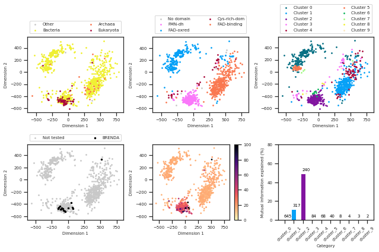

```python
from seqsample.seqsample import mi_for_selection

fig = plt.figure(figsize=(9, 6))

xlab = 'Dimension 1'
ylab = 'Dimension 2'



# first plot (superkingdoms)
bac = prop_data.superkingdom == 'Bacteria'
arc = prop_data.superkingdom == 'Archaea'
euk = prop_data.superkingdom == 'Eukaryota'
oth = [not any(s) for s in zip(bac, arc, euk)]

plt.subplot(2, 3, 1)
plt.scatter(my_plot[:,0][oth], my_plot[:,1][oth], s=small_point, color=other)
plt.scatter(my_plot[:,0][bac], my_plot[:,1][bac], s=small_point, color=bacteria)
plt.scatter(my_plot[:,0][arc], my_plot[:,1][arc], s=small_point, color=archaea)
plt.scatter(my_plot[:,0][euk], my_plot[:,1][euk], s=small_point, color=eukaryota)
#plt.gca().get_xaxis().set_ticklabels([])
#plt.gca().get_yaxis().set_ticklabels([])
plt.legend(['Other', 'Bacteria', 'Archaea', 'Eukaryota'],
           fontsize=font_size,
           loc='lower left',
           bbox_to_anchor=(0, 1.02, 1, 0.2),
           mode = 'expand',
           ncol=2)
plt.xlabel(xlab,fontsize=font_size)
plt.ylabel(ylab,fontsize=font_size)
plt.tick_params(labelsize=font_size)

# # add subplot ordinal letters
# plt.text(0, 0, '(%s)' % string.ascii_lowercase[0],
#             size=10, weight='bold', transform=plt.gcf().transFigure)

# ax.annotate('(%s)' % string.ascii_lowercase[0],
#             xy=(0.5, 0), xytext=(0, 10),
#             xycoords=('axes fraction', 'figure fraction'),
#             textcoords='offset points',
#             size=14, ha='center', va='bottom')

# second plot (domain info)
PF01070 = [True if 'PF01070' in s else False for s in  prop_data.pfam.values] # PF01070, FMN dehydrogenase
PF01266 = [True if 'PF01266' in s else False for s in  prop_data.pfam.values] # PF01266, FAD dependent oxidoreductase family
PF02754 = [True if 'PF02754' in s else False for s in  prop_data.pfam.values] # PF02754, Cys-rich-dom
PF01565 = [True if 'PF01565' in s else False for s in  prop_data.pfam.values] # PF01565, FAD_binding_4
background = [not any(s) for s in zip(PF01266, PF01070, PF02754, PF01565)]

plt.subplot(2, 3, 2)
plt.scatter(my_plot[:,0][background], my_plot[:,1][background], s=small_point, color=other)
plt.scatter(my_plot[:,0][PF01070], my_plot[:,1][PF01070], s=small_point, color=cluster3)
plt.scatter(my_plot[:,0][PF01266], my_plot[:,1][PF01266], s=small_point, color=cluster1)
plt.scatter(my_plot[:,0][PF02754], my_plot[:,1][PF02754], s=small_point, color=cluster4)
plt.scatter(my_plot[:,0][PF01565], my_plot[:,1][PF01565], s=small_point, color=cluster5)
#plt.gca().get_xaxis().set_ticklabels([])
#plt.gca().get_yaxis().set_ticklabels([])
plt.legend(['No domain', 'FMN-dh', 'FAD-oxred', 'Cys-rich-dom', 'FAD-binding'],
           fontsize=font_size,
           loc='lower left',
           bbox_to_anchor=(0, 1.02, 1, 0.2),
           mode = 'expand',
           ncol=2)
plt.xlabel(xlab,fontsize=font_size)
plt.ylabel(ylab,fontsize=font_size)
plt.tick_params(labelsize=font_size)


# third plot (clusters)
cluster_0 = prop_data.cluster == 'cluster_0'
cluster_1 = prop_data.cluster == 'cluster_1'
cluster_2 = prop_data.cluster == 'cluster_2'
cluster_3 = prop_data.cluster == 'cluster_3'
cluster_4 = prop_data.cluster == 'cluster_4'
cluster_5 = prop_data.cluster == 'cluster_5'
cluster_6 = prop_data.cluster == 'cluster_6'
cluster_7 = prop_data.cluster == 'cluster_7'
cluster_8 = prop_data.cluster == 'cluster_8'
cluster_9 = prop_data.cluster == 'cluster_9'

plt.subplot(2, 3, 3)
plt.scatter(my_plot[:,0][cluster_0], my_plot[:,1][cluster_0], s=small_point, color=cluster0)
plt.scatter(my_plot[:,0][cluster_1], my_plot[:,1][cluster_1], s=small_point, color=cluster1)
plt.scatter(my_plot[:,0][cluster_2], my_plot[:,1][cluster_2], s=small_point, color=cluster2)
plt.scatter(my_plot[:,0][cluster_3], my_plot[:,1][cluster_3], s=small_point, color=cluster3)
plt.scatter(my_plot[:,0][cluster_4], my_plot[:,1][cluster_4], s=small_point, color=cluster4)
plt.scatter(my_plot[:,0][cluster_5], my_plot[:,1][cluster_5], s=small_point, color=cluster5)
plt.scatter(my_plot[:,0][cluster_6], my_plot[:,1][cluster_6], s=small_point, color=cluster6)
plt.scatter(my_plot[:,0][cluster_7], my_plot[:,1][cluster_7], s=small_point, color=cluster7)
plt.scatter(my_plot[:,0][cluster_8], my_plot[:,1][cluster_8], s=small_point, color=cluster8)
plt.scatter(my_plot[:,0][cluster_9], my_plot[:,1][cluster_9], s=small_point, color=cluster9)
#plt.gca().get_xaxis().set_ticklabels([])
#plt.gca().get_yaxis().set_ticklabels([])
plt.legend(['Cluster 0', 'Cluster 1',
            'Cluster 2', 'Cluster 3',
            'Cluster 4', 'Cluster 5',
            'Cluster 6', 'Cluster 7',
            'Cluster 8', 'Cluster 9'],
           fontsize=font_size,
           loc='lower left',
           bbox_to_anchor=(0, 1.02, 1, 0.2),
           mode = 'expand',
           ncol=2)
plt.xlabel(xlab,fontsize=font_size)
plt.ylabel(ylab,fontsize=font_size)
plt.tick_params(labelsize=font_size)


# fourth plot (characterized)
background = prop_data.in_brenda.values == 'No'
bren = prop_data.in_brenda == 'Yes'

plt.subplot(2, 3, 4)
plt.scatter(my_plot[:,0][background], my_plot[:,1][background], s=small_point, color=other)
plt.scatter(my_plot[:,0][bren], my_plot[:,1][bren], s=large_point, color=brenda)
#plt.gca().get_xaxis().set_ticklabels([])
#plt.gca().get_yaxis().set_ticklabels([])
plt.legend(['Not tested', 'BRENDA'],
           fontsize=font_size,
           loc='lower left',
           bbox_to_anchor=(0, 1.02, 1, 0.2),
           mode = 'expand',
           ncol=2)
plt.xlabel(xlab,fontsize=font_size)
plt.ylabel(ylab,fontsize=font_size)
plt.tick_params(labelsize=font_size)



# fifth plot (SwissProt identity t-SNE)
plt.subplot(2, 3, 5)

sc = plt.scatter(my_plot[:,0], my_plot[:,1],
                 s=small_point,
                 c=prop_data.max_brenda_sim.values,
                 cmap='magma_r', # low contrast: 'viridis' 'plasma' high contrast: 'inferno' 'magma'
                 vmin=0,
                 vmax=100)
#plt.gca().get_xaxis().set_ticklabels([])
#plt.gca().get_yaxis().set_ticklabels([])
plt.xlabel('Dimension 1',fontsize=font_size)
plt.ylabel('Dimension 2',fontsize=font_size)
cb = fig.colorbar(sc)
cb.ax.tick_params(labelsize=font_size)
plt.tick_params(labelsize=font_size)




# sixth plot (mutual information)
plt.subplot(2, 3, 6)


# first I need to get the data
data = {'cluster':[], 'brenda_mi':[], 'count':[]}

clusters = list(set(prop_data.cluster.values))
for clust in sorted(clusters):
    # first subset that cluster
    cluster_data = prop_data[prop_data.cluster == clust]

    # count the sequences
    num_seq = len(cluster_data.uid.values)

    # now get identifiers in that cluster
    selected = cluster_data[cluster_data.in_brenda == 'Yes'].uid.values

    # compute mutual information
    filepath = join(FINAL, 'BRENDA', '%s_alignment.fasta' % clust)
    mi = mi_for_selection(alignment_path=filepath, preselected=selected, unwanted=[])

    # add to data structure
    data['cluster'].append(clust)
    data['count'].append(num_seq)
    data['brenda_mi'].append(mi)

result = pd.DataFrame(data)
display(result)


# now make the plot
N = len(list(set(result.cluster)))
mi_data = result.brenda_mi.values
ind = np.arange(N)    # the x locations for the groups
width = 0.5       # the width of the bars: can also be len(x) sequence

p1 = plt.bar(ind, mi_data, width,
            color=colors)

# add labels on top of bars
for i, v in enumerate(result['count'].values):
    plt.text(x=i-0.1,
             y=mi_data[i]+max(mi_data)*0.05,
             s=str(v),
             color='black',
             fontweight='normal',
             fontsize=font_size)


# tweak the axis
plt.ylabel('Count')
plt.xticks(ind, result.cluster.values, rotation=45)
plt.yticks(np.arange(0, 100, 20))
plt.xlabel('Category', fontsize=font_size)
plt.ylabel('Mutual information explained (%)', fontsize=font_size)
plt.tick_params(labelsize=font_size)

plt.tight_layout()



plt.savefig(join(FIGURES, 'figure1.png'), dpi=300, facecolor='w', edgecolor='w',
        orientation='portrait', papertype=None, format=None,
        transparent=False, bbox_inches=None, pad_inches=0.1,
        frameon=None, metadata=None)
```

#### Figure S1: Histogram of identities

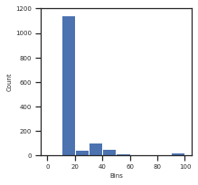

```python
fig = plt.figure(figsize=(3, 3))

plt.hist(prop_data.max_brenda_sim,
         bins=10,
         range=(0, 100))  # arguments are passed to np.histogram


# tweak the axis
plt.ylabel('Count', fontsize=font_size)
plt.xlabel('Bins', fontsize=font_size)
plt.tick_params(labelsize=font_size)


plt.savefig(join(FIGURES, 'figure_S1.png'), dpi=300, facecolor='w', edgecolor='w',
        orientation='portrait', papertype=None, format=None,
        transparent=False, bbox_inches=None, pad_inches=0.1,
        frameon=None, metadata=None)
```

#### Figure 2: plot data from the experiments, soluble active etc (6 plots)

|  | superkingdom | Insoluble | Inactive | Active | count |
| --- | --- | --- | --- | --- | --- |
| 0 | Archaea | 0.714286 | 0.142857 | 0.142857 | 7 |
| 1 | Bacteria | 0.423077 | 0.394231 | 0.182692 | 104 |
| 2 | Eukaryota | 0.727273 | 0.181818 | 0.090909 | 11 |

|  | cluster | Insoluble | Inactive | Active | count |
| --- | --- | --- | --- | --- | --- |
| 0 | cluster_0 | 0.517241 | 0.344828 | 0.137931 | 29 |
| 1 | cluster_1 | 0.393939 | 0.454545 | 0.151515 | 33 |
| 2 | cluster_2 | 0.405405 | 0.297297 | 0.297297 | 37 |
| 3 | cluster_3 | 0.875000 | 0.125000 | 0.000000 | 8 |
| 4 | cluster_4 | 0.571429 | 0.428571 | 0.000000 | 7 |
| 5 | cluster_5 | 0.000000 | 0.500000 | 0.500000 | 2 |
| 6 | cluster_6 | 0.000000 | 1.000000 | 0.000000 | 2 |
| 7 | cluster_7 | 0.500000 | 0.500000 | 0.000000 | 2 |
| 8 | cluster_8 | 1.000000 | 0.000000 | 0.000000 | 1 |
| 9 | cluster_9 | 1.000000 | 0.000000 | 0.000000 | 1 |

|  | cluster | active_mi | count |
| --- | --- | --- | --- |
| 0 | cluster_0 | 41.337651 | 645 |
| 1 | cluster_1 | 36.996165 | 317 |
| 2 | cluster_2 | 60.537420 | 240 |
| 3 | cluster_3 | 0.000000 | 84 |
| 4 | cluster_4 | 0.000000 | 68 |
| 5 | cluster_5 | 22.597892 | 40 |
| 6 | cluster_6 | 0.000000 | 8 |
| 7 | cluster_7 | 0.000000 | 4 |
| 8 | cluster_8 | 0.000000 | 3 |
| 9 | cluster_9 | 0.000000 | 2 |

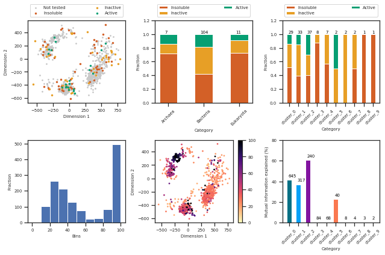

```python
fig = plt.figure(figsize=(9, 6))


# first plot, (insoluble, inactive, active, t-SNE plot)
background = (prop_data.total_soluble != 'No') & (prop_data.total_active != 'No') & (prop_data.total_active != 'Yes')
insol = prop_data.total_soluble == 'No'
inact = (prop_data.total_soluble == 'Yes') & (prop_data.total_active == 'No')
act = (prop_data.total_soluble == 'Yes') & (prop_data.total_active == 'Yes')

plt.subplot(2, 3, 1)
plt.scatter(my_plot[:,0][background], my_plot[:,1][background], s=small_point, color=other)
plt.scatter(my_plot[:,0][insol], my_plot[:,1][insol], s=large_point, color=insoluble)
plt.scatter(my_plot[:,0][inact], my_plot[:,1][inact], s=large_point, color=inactive)
plt.scatter(my_plot[:,0][act], my_plot[:,1][act], s=large_point, color=active)
#plt.gca().get_xaxis().set_ticklabels([])
#plt.gca().get_yaxis().set_ticklabels([])
plt.legend(['Not tested', 'Insoluble', 'Inactive', 'Active'],
           fontsize=font_size,
           loc='lower left',
           bbox_to_anchor=(0, 1.02, 1, 0.2),
           mode = 'expand',
           ncol=2)
plt.xlabel('Dimension 1', fontsize=font_size)
plt.ylabel('Dimension 2', fontsize=font_size)
plt.tick_params(labelsize=font_size)




# second plot (sequences per superkingdom, indicating soluble and insoluble fraction, stacked barchart)
plt.subplot(2, 3, 2)

# make a subset to get the sequences of interest
df_subset = prop_data.loc[prop_data['synthesized']=='Yes']
df_subset = df_subset.loc[prop_data['substrate_available']=='Yes']

# count the frequencies
df_temp = df_subset
df_temp.total_active = df_temp.total_active.replace(np.nan, '', regex=True)
result = df_temp.groupby('superkingdom')['total_active'].value_counts(normalize=True)
result = result.unstack().fillna(0)
result = result.reset_index()
result.rename(index=str, columns={'No': 'Inactive', 'Yes': 'Active', '':'Insoluble'}, inplace=True)

# count the total number per category
result_count = df_temp.groupby('superkingdom')['uid'].nunique()
result_count = pd.DataFrame(result_count)
result_count = result_count.reset_index()
result_count.rename(index=str, columns={'uid': 'count'}, inplace=True)

# join the two
result = result.merge(result_count, on='superkingdom')

display(result)


# now plot
N = len(list(set(result.superkingdom)))
insol = result.Insoluble.values
inact = result.Inactive.values
act = result.Active.values
ind = np.arange(N)    # the x locations for the groups
width = 0.5       # the width of the bars: can also be len(x) sequence

p1 = plt.bar(ind, insol, width,
            color=insoluble)
p2 = plt.bar(ind, inact, width,
             bottom=insol,
            color=inactive)
p3 = plt.bar(ind, act, width,
             bottom=insol+inact,
            color=active)

# add labels on top of bars
for i, v in enumerate(result['count'].values):
    plt.text(x=i-0.1,
             y=1.01,
             s=str(v),
             color='black',
             fontweight='normal',
             fontsize=font_size)

# tweak the axis
plt.xticks(ind, result.superkingdom.values, rotation=45)
plt.yticks(np.arange(0, 1.3, 0.2))
plt.legend((p1[0], p2[0], p3[0]), ('Insoluble', 'Inactive', 'Active'),
           fontsize=font_size,
           loc='lower left',
           bbox_to_anchor=(0, 1.02, 1, 0.2),
           mode = 'expand',
           ncol=2)
plt.xlabel('Category', fontsize=font_size)
plt.ylabel('Fraction', fontsize=font_size)
plt.tick_params(labelsize=font_size)


# third plot (sequences per cluster, indicating soluble and insoluble fraction, stacked barchart)
plt.subplot(2, 3, 3)

# count the frequencies
df_temp = df_subset
df_temp.total_active = df_temp.total_active.replace(np.nan, '', regex=True)
result = df_temp.groupby('cluster')['total_active'].value_counts(normalize=True)
result = result.unstack().fillna(0)
result = result.reset_index()
result.rename(index=str, columns={'No': 'Inactive', 'Yes': 'Active', '':'Insoluble'}, inplace=True)

# count the total number per category
result_count = df_subset.groupby('cluster')['uid'].nunique()
result_count = pd.DataFrame(result_count)
result_count = result_count.reset_index()
result_count.rename(index=str, columns={'uid': 'count'}, inplace=True)

# join the two
result = result.merge(result_count, on='cluster')

display(result)


# now plot
N = len(list(set(result.cluster)))
insol = result.Insoluble.values
inact = result.Inactive.values
act = result.Active.values
ind = np.arange(N)    # the x locations for the groups
width = 0.5       # the width of the bars: can also be len(x) sequence

p1 = plt.bar(ind, insol, width,
            color=insoluble)
p2 = plt.bar(ind, inact, width,
             bottom=insol,
            color=inactive)
p3 = plt.bar(ind, act, width,
             bottom=insol+inact,
            color=active)

# add labels on top of bars
for i, v in enumerate(result['count'].values):
    plt.text(x=i-0.1,
             y=1.01,
             s=str(v),
             color='black',
             fontweight='normal',
             fontsize=font_size)

# tweak the axis
plt.ylabel('Fraction')
plt.xticks(ind, result.cluster.values, rotation=45)
plt.yticks(np.arange(0, 1.3, 0.2))
plt.legend((p1[0], p2[0], p3[0]), ('Insoluble', 'Inactive', 'Active'),
           fontsize=font_size,
           loc='lower left',
           bbox_to_anchor=(0, 1.02, 1, 0.2),
           mode = 'expand',
           ncol=2)
plt.xlabel('Category', fontsize=font_size)
plt.ylabel('Fraction', fontsize=font_size)
plt.tick_params(labelsize=font_size)



# fourth plot histogram of the identities
plt.subplot(2, 3, 4)

plt.hist(prop_data.max_all_sim,
         bins=10,
         range=(0, 100))  # arguments are passed to np.histogram


# tweak the axis
plt.ylabel('Fraction', fontsize=font_size)
plt.xlabel('Bins', fontsize=font_size)
plt.tick_params(labelsize=font_size)



# fith plot (SwissProt identity t-SNE)
plt.subplot(2, 3, 5)

sc = plt.scatter(my_plot[:,0], my_plot[:,1],
                 s=small_point,
                 c=prop_data.max_all_sim.values,
                 cmap='magma_r', # low contrast: 'viridis' 'plasma' high contrast: 'inferno' 'magma'
                 vmin=0,
                 vmax=100)
#plt.gca().get_xaxis().set_ticklabels([])
#plt.gca().get_yaxis().set_ticklabels([])
plt.xlabel('Dimension 1',fontsize=font_size)
plt.ylabel('Dimension 2',fontsize=font_size)
cb = fig.colorbar(sc)
cb.ax.tick_params(labelsize=font_size)
plt.tick_params(labelsize=font_size)


# sixth plot, mutual information explained by all
plt.subplot(2, 3, 6)


# first I need to get the data
data = {'cluster':[], 'active_mi':[], 'count':[]}

clusters = list(set(prop_data.cluster.values))
for clust in sorted(clusters):
    # first subset that cluster
    cluster_data = prop_data[prop_data.cluster == clust]

    # count the sequences
    num_seq = len(cluster_data.uid.values)

    # now get identifiers in that cluster
    selected = cluster_data[cluster_data.total_active == 'Yes'].uid.values

    # compute mutual information
    filepath = join(FINAL, 'BRENDA', '%s_alignment.fasta' % clust)
    mi = mi_for_selection(alignment_path=filepath, preselected=selected, unwanted=[])

    # add to data structure
    data['cluster'].append(clust)
    data['count'].append(num_seq)
    data['active_mi'].append(mi)

result = pd.DataFrame(data)
display(result)


# now make the plot
N = len(list(set(result.cluster)))
mi_data = result.active_mi.values
ind = np.arange(N)    # the x locations for the groups
width = 0.5       # the width of the bars: can also be len(x) sequence

p1 = plt.bar(ind, mi_data, width,
            color=colors)

# add labels on top of bars
for i, v in enumerate(result['count'].values):
    plt.text(x=i-0.1,
             y=mi_data[i]+max(mi_data)*0.05,
             s=str(v),
             color='black',
             fontweight='normal',
             fontsize=font_size)

# tweak the axis
plt.ylabel('Count')
plt.xticks(ind, result.cluster.values, rotation=45)
plt.yticks(np.arange(0, 100, 20))
plt.xlabel('Category', fontsize=font_size)
plt.ylabel('Mutual information explained (%)', fontsize=font_size)
plt.tick_params(labelsize=font_size)


plt.tight_layout()

plt.savefig(join(FIGURES, 'figure2.png'), dpi=300, facecolor='w', edgecolor='w',
        orientation='portrait', papertype=None, format=None,
        transparent=False, bbox_inches=None, pad_inches=0.1,
        frameon=None, metadata=None)
```

```python
temp_df = prop_data[(prop_data.total_soluble == 'Yes') & (prop_data.total_active == 'Yes')]
temp_df[['uid', 'superkingdom', 'pfam', 'cluster']]
```

|  | uid | superkingdom | pfam | cluster |
| --- | --- | --- | --- | --- |
| 212 | A4YVE0 | Bacteria | PF01070 | cluster_2 |
| 293 | B8MKR3 | Eukaryota | PF00173,PF01070 | cluster_2 |
| 338 | C4VMW0 | Bacteria | PF01070 | cluster_2 |
| 496 | A0A087D1R1 | Bacteria | PF01070 | cluster_2 |
| 587 | C9Y9E7 | Bacteria | PF01070 | cluster_2 |
| 632 | B7N6P4 | Bacteria | PF01266 | cluster_0 |
| 659 | D4MUV9 | Bacteria | PF01565,PF02913 | cluster_1 |
| 671 | C2K1F0 | Bacteria | PF01070 | cluster_2 |
| 740 | S2DJ52 | Bacteria | PF01266 | cluster_0 |
| 808 | A0A0U6K8E5 | Bacteria | PF01266 | cluster_0 |
| 908 | Q5WIP4 | Bacteria | PF01565,PF02913 | cluster_1 |
| 915 | A0A077SBA9 | Bacteria | PF01565,PF02913 | cluster_1 |
| 996 | W6W585 | Bacteria | PF01070 | cluster_2 |
| 998 | B1HZY7 | Bacteria | PF01070 | cluster_2 |
| 1087 | R0EVG9 | Bacteria | PF01266 | cluster_0 |
| 1105 | B7RR92 | Bacteria | PF01070 | cluster_2 |
| 1257 | D4N087 | Bacteria | PF01565,PF02913 | cluster_1 |
| 1383 | A0A011QK89 | Bacteria | PF01266 | cluster_5 |
| 1388 | E6SCX5 | Bacteria | PF01070 | cluster_2 |
| 1401 | A0A087RXW1 | Archaea | PF01565,PF02913 | cluster_1 |
| 1407 | A9QH69 | Bacteria | PF01070 | cluster_2 |

#### Figure 3: "phylogenetic tree" view with the substrates

```python
import abc_tools
import vislib

from scipy.spatial.distance import squareform
from scipy.cluster.hierarchy import dendrogram, linkage
```

```python
def filter_matrix_for_ids(data_matrix, id_list):
    '''
    Subset a pairwise identity matrix to retain only the desired identifiers.
    '''
    # make sure all the identifiers are present in the identity matrix
    for uid in id_list:
        assert uid in data_matrix.index, 'Error, %s not present in identity matrix' % uid

    for uid in id_list:
        assert uid in data_matrix.index, 'Error, %s not present in identity matrix' % uid


    # make a subset of the identity matrix
    return data_matrix.loc[id_list, id_list]


def den_from_id_matrix(data_matrix, linkage_type='average'):
    '''
    Build a dendrogram from the pre-computed pairwise protein idnetities.
    '''

    # convert the similarity matrix to a distance matrix
    data_dist_matrix = data_matrix.apply(lambda value: 100-value)

    # cut the matrix in half (condensed distance matrix)
    dists = squareform(data_dist_matrix.values)

    # make a linkage matrix
    linkage_matrix = linkage(dists, linkage_type)

    # make dendrogram object
    den = dendrogram(linkage_matrix, labels=data_dist_matrix.index)

    #plt.show()

    return den


# get the dendrogram plotting data coordinates
def extract_plotting_coordinates(den):
    '''
    Get the x, y coordinates for ach index.
    '''
    x_coordinates = den['icoord']
    y_coordinates = den['dcoord']
    index = den['ivl']
    coordinate_data = []
    label_data = {}
    i = 0
    # the dendrogram is drawn as "half boxes" with each point described by a list of four x and four y coordinates
    # extract these for later plotting
    for x_list, y_list in zip(x_coordinates, y_coordinates):
        xy_pairs = zip(x_list, y_list)
        # also want to get the end nodes, where the labels are supposed to go
        pairs = []
        for x, y in xy_pairs:
            pair = (x, y)
            pairs.append(pair)
            # if y is zero, then that is a place where the label should go
            if y == 0.0:
                label_data[index[i]] = pair
                i += 1
        coordinate_data.append(pairs)
    return coordinate_data, label_data
```

|  | uid | taxid | organism | superkingdom | ph | temperature | ec | synthesized | substrate_available | total_soluble | ... | 2-hydroxyglutarate | 2-hydroxyoctanoate | 2-hydroxystearate | mandelate | in_brenda | cluster | pfam | max_brenda_sim | max_active_sim | max_all_sim |
| --- | --- | --- | --- | --- | --- | --- | --- | --- | --- | --- | --- | --- | --- | --- | --- | --- | --- | --- | --- | --- | --- |
| 47 | A0A073CBY9 | 388467.0 | Planktothrix agardhii | Bacteria | NaN | 21.0 | 1.1.3.15 | Yes | Yes | Yes | ... | No | No | No | No | No | cluster_1 | PF01565 | 16.6 | 21.8 | 21.8 |
| 70 | C0XIJ3 | 1423757.0 | Lactobacillus hilgardii | Bacteria | 6.35 | 33.0 | 1.1.3.15 | Yes | Yes | Yes | ... | No | No | No | No | No | cluster_2 | PF01070 | 57.0 | 47.3 | 57.0 |
| 87 | A0A0J6V898 | 1800.0 | Mycolicibacterium chubuense | Bacteria | NaN | NaN | 1.1.3.15 | Yes | Yes | Yes | ... | No | No | No | No | No | cluster_0 | PF01266,PF04324 | 17.4 | 22.5 | 22.5 |
| 151 | Q15TJ7 | 342610.0 | Pseudoalteromonas atlantica | Bacteria | 7.60 | 22.0 | 1.1.3.15 | Yes | Yes | Yes | ... | No | No | No | No | No | cluster_2 | PF01070 | 38.4 | 40.2 | 40.2 |
| 154 | B8MMC0 | 441959.0 | Talaromyces stipitatus | Eukaryota | 5.60 | 25.0 | 1.1.3.15 | Yes | Yes | Yes | ... | No | No | No | No | No | cluster_2 | PF00173,PF01070 | 26.8 | 40.2 | 40.2 |

5 rows × 24 columns

```
(65, 65)
```

```
<vislib.substrate at 0x7f8a84609630>
```

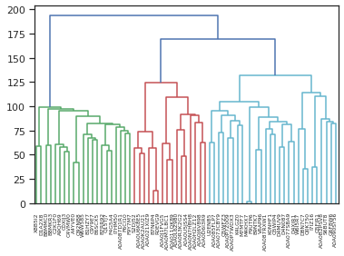

```python
# select all soluble sequences
df_subset = prop_data.loc[prop_data['total_soluble']=='Yes']
display(df_subset.head())

soluble_ids = df_subset.uid.values

# filter the identity matrix to contain only these
data_matrix = filter_matrix_for_ids(data_matrix=df_ident, id_list=soluble_ids)
display(data_matrix.shape)


# make dendrogram
den = den_from_id_matrix(data_matrix, linkage_type='ward')

# get info from the dendrogam
coordinate_data, label_data = extract_plotting_coordinates(den)

# load up the data from both batches
data1 = pd.read_csv(join(FINAL, 'experiments', '1.1.3.15_detailed_batch1.csv'), sep=';', index_col=0)
data2 = pd.read_csv(join(FINAL, 'experiments', '1.1.3.15_detailed_batch2.csv'), sep=';', index_col=0)
substrate_data = data1.append(data2)

# keep only soluble ones
substrate_data = substrate_data.loc[soluble_ids]

# convert to a dictionary
substrate_data_dict = substrate_data.to_dict('index')

# # look at one entry
# substrate_data[list(data_dict.keys())[0]]

# get a dictionary with properties that I want to color
property_frame = df_subset[['uid', 'superkingdom', 'cluster', 'total_active']].set_index('uid')
property_dict = property_frame.to_dict('index')



# assign property colors
property_colors = {'cluster':{'cluster_0':cluster0, 'cluster_1':cluster1, 'cluster_2':cluster2,
                              'cluster_3':cluster3, 'cluster_4':cluster4, 'cluster_5':cluster5,
                              'cluster_6':cluster6, 'cluster_7':cluster7, 'cluster_8':cluster8,
                              'cluster_9':cluster9},
                   'total_active':{'No':inactive, 'Yes':active},
                   'superkingdom':{'Archaea':archaea,'Bacteria':bacteria, 'Eukaryota':eukaryota, 'Other':other}}


# make the plot
vislib.substrate(data=label_data,
                 dend_data=coordinate_data,
                 subst_data=substrate_data_dict,
                 subst_data_replicate=substrate_data_dict,
                 property_dict=property_dict,
                 property_colors=property_colors,
                 filepath=join(FIGURES, 'figure3.svg'),
                 main='1.1.3.15')
```

#### Look across the sequences to see how the MI algorithm sampled

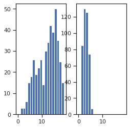

```
total
1     100.000000
2      50.000000
3      38.888889
4      31.666667
5      37.777778
6      30.769231
7      31.578947
8      26.704545
9      21.794872
10     28.571429
11     20.000000
12     22.303922
13     21.611722
14     19.230769
15     19.333333
16     20.000000
17     18.117647
18     15.740741
19     21.052632
Name: sampled_percent, dtype: float64
```

```
total  sampled
1      1           3
2      1           3
3      1           5
       2           1
4      1          11
                  ..
18     4           2
       1           1
19     3           1
       4           1
       5           1
Name: sampled, Length: 63, dtype: int64
```

```python
from seqsample import distance
from Bio import SeqIO

# load up the alignments and collect all the sequences
alignment_path = join(FINAL, 'BRENDA', 'cluster_0_alignment.fasta')
headers = []
all_seq = []
active_seq = []

for record in SeqIO.parse(alignment_path, "fasta"):
    header = record.id.split(';')[0]
    seq = record.seq

    headers.append(header)
    all_seq.append(seq)

    if header in prop_data[prop_data.total_active=='Yes'].uid.values:
        active_seq.append(seq)




def count_symbols_per_pos(seq_list, selected_seq_list, gap_cutoff=0.75):
    '''
    Count how many symbols occur at each position in an alignment.
    Exclude positions where the number of gaps are above specified cutoff.
    '''
    counts = [[] for s in range(len(seq_list[0]))]
    for line in seq_list:
        for i, symbol in enumerate(line):
            #if symbol == '-':
            #    continue
            counts[i].append(symbol.lower())

    selected_counts = [[] for s in range(len(seq_list[0]))]
    for line in selected_seq_list:
        for i, symbol in enumerate(line):
            #if symbol == '-':
            #    continue
            selected_counts[i].append(symbol.lower())

    # now remove positions with too many gaps
    no_gap_counts = []
    no_gap_selected_counts = []
    for i, c in enumerate(counts):
        if c.count('-')/len(c) < gap_cutoff:
            no_gap_counts.append(c)
            no_gap_selected_counts.append(selected_counts[i])


    return [len(set(s)) if '-' not in s else len(set(s))-1 for s in no_gap_counts], [len(set(s)) if '-' not in s else len(set(s))-1 for s in no_gap_selected_counts],


all_counts, selected_counts = count_symbols_per_pos(all_seq, active_seq)



# plot histograms of how many amino acids are present at different positions
plt.figure()

plt.subplot(1,3,1)
plt.hist(all_counts, bins=range(0,20))

plt.subplot(1,3,2)
plt.hist(selected_counts, bins=range(0,20))

plt.show()



# make a data frame
x = pd.DataFrame({'total':all_counts, 'sampled':selected_counts})

x['sampled_percent'] = 100*x.sampled/x.total

# count the frequencies
result = x.groupby('total')['sampled_percent'].mean()
display(result)

# count the frequencies
result = x.groupby('total')['sampled'].value_counts()
display(result)
```

For each sequence I need to get the max identity to the categories of substrate speceficity

```python
# combine uid property data with ec information
uid_data = uid_property.merge(uid_ec, on='uid')

# subset to keep only 1.1.3.15
uid_data_subset = uid_data[uid_data['ec']=='1.1.3.15']

# move index column of the substrate data to a new uid column
substrate_data['uid'] = substrate_data.index

# combine with the substrate-specific data
props_and_experiments = uid_data_subset.merge(substrate_data,
                     on='uid',
                     how='left')

# change True to Yes and False to No
props_and_experiments.replace(True, 'Yes', regex=False, inplace=True)
props_and_experiments.replace(False, 'No', regex=False, inplace=True)

# sort property data to be in the same order as the other data
props_and_experiments['sort_cat'] = pd.Categorical(props_and_experiments['uid'],
                                          categories=prop_data.uid,
                                          ordered=True)
props_and_experiments.sort_values('sort_cat', inplace=True)
props_and_experiments.reset_index(inplace=True)
props_and_experiments = props_and_experiments.drop(['sort_cat', 'index'], axis=1)


# filter the identity matrix to contain only the identifiers that I'm using
identity_data = filter_matrix_for_ids(data_matrix=df_ident, id_list=props_and_experiments.uid.values)
display(identity_data.shape)

# sort identity data to be in the same order as the other
identity_data['uid'] = identity_data.index
identity_data['sort_cat'] = pd.Categorical(identity_data['uid'],
                                          categories=prop_data.uid,
                                          ordered=True)
identity_data.sort_values('sort_cat', inplace=True)
identity_data.reset_index(inplace=True)

# put back the index and drop unneeded columns
identity_data.index = identity_data.uid
identity_data = identity_data.drop(['sort_cat', 'index', 'uid'], axis=1)


# get only the substrate columns
data_substrates = props_and_experiments[['glycolate', 'lactate', 'mandelate', '2-hydroxyglutarate', '2-hydroxyoctanoate', '2-hydroxystearate']]
count_result = data_substrates.apply(pd.Series.value_counts, axis=1)[['Yes']].fillna(0)

substrates = ['promiscuous', 'glycolate',
              'lactate', 'mandelate',
            '2-hydroxyglutarate']
for i, subst in enumerate(substrates):

    if subst == 'promiscuous':
        selected = props_and_experiments[count_result['Yes'] >= 3]

    elif subst == 'glycolate':
        selected = props_and_experiments[(props_and_experiments['glycolate'] == 'Yes') & (count_result['Yes'] == 1)]

    elif subst == 'lactate':
        selected = props_and_experiments[(props_and_experiments['lactate'] == 'Yes') & (count_result['Yes'] == 1)]

    elif subst == 'mandelate':
        selected = props_and_experiments[(props_and_experiments['mandelate'] == 'Yes') & (count_result['Yes'] == 1)]

    elif subst == '2-hydroxyglutarate':
        selected = props_and_experiments[(props_and_experiments['2-hydroxyglutarate'] == 'Yes') & (count_result['Yes'] == 1)]



    # # get a list with all the identifiers not selected
    # not_selected = moran_subset[moran_subset.in_brenda == 'No']

    # # make sure all the identifiers are present in the identity matrix
    # for uid in selected.uid.values:
    #     assert uid in df_ident.index, 'Error, %s not present in identity matrix' % uid

    # for uid in not_selected.uid.values:
    #     assert uid in df_ident.index, 'Error, %s not present in identity matrix' % uid


    # make a subset of the identity matrix
    df_ident_selected = identity_data.loc[selected.uid.values]

    ident_key = '%s_sim' % subst
    sim_data = {'uid':[], ident_key:[]}
    for uid in props_and_experiments.uid.values:
        sim_data['uid'].append(uid)
        sim_data[ident_key].append(max(df_ident_selected[uid].values))


    # merge with the other data
    sim_data_df = pd.DataFrame(sim_data)
    props_and_experiments = props_and_experiments.merge(sim_data_df, on=['uid'])

display(props_and_experiments.head())
display(props_and_experiments.tail())
```

```
(1411, 1411)
```

|  | uid | taxid | organism | superkingdom | ph | temperature | pfam | ec | glycolate | lactate | 2-hydroxyglutarate | 2-hydroxyoctanoate | 2-hydroxystearate | mandelate | promiscuous_sim | glycolate_sim | lactate_sim | mandelate_sim | 2-hydroxyglutarate_sim |
| --- | --- | --- | --- | --- | --- | --- | --- | --- | --- | --- | --- | --- | --- | --- | --- | --- | --- | --- | --- |
| 0 | Q9LRS0 | 3702.0 | Arabidopsis thaliana | Eukaryota | NaN | NaN | NaN | 1.1.3.15 | NaN | NaN | NaN | NaN | NaN | NaN | 35.9 | 13.0 | 38.5 | 13.8 | 16.1 |
| 1 | Q9NYQ3 | 9606.0 | Homo sapiens | Eukaryota | NaN | NaN | NaN | 1.1.3.15 | NaN | NaN | NaN | NaN | NaN | NaN | 35.0 | 12.6 | 37.7 | 15.0 | 15.2 |
| 2 | P37339 | 83333.0 | Escherichia coli | Bacteria | 7.01 | 36.0 | NaN | 1.1.3.15 | NaN | NaN | NaN | NaN | NaN | NaN | 15.8 | 12.7 | 15.9 | 16.5 | 87.0 |
| 3 | Q24JJ8 | 3702.0 | Arabidopsis thaliana | Eukaryota | NaN | NaN | NaN | 1.1.3.15 | NaN | NaN | NaN | NaN | NaN | NaN | 35.9 | 14.1 | 36.6 | 12.8 | 16.5 |
| 4 | B8AUI3 | 39946.0 | Oryza sativa | Eukaryota | NaN | NaN | NaN | 1.1.3.15 | NaN | NaN | NaN | NaN | NaN | NaN | 37.3 | 10.6 | 37.8 | 15.4 | 18.0 |

|  | uid | taxid | organism | superkingdom | ph | temperature | pfam | ec | glycolate | lactate | 2-hydroxyglutarate | 2-hydroxyoctanoate | 2-hydroxystearate | mandelate | promiscuous_sim | glycolate_sim | lactate_sim | mandelate_sim | 2-hydroxyglutarate_sim |
| --- | --- | --- | --- | --- | --- | --- | --- | --- | --- | --- | --- | --- | --- | --- | --- | --- | --- | --- | --- |
| 1406 | D5MNA0 | 671143.0 | Candidatus methylomirabilis | Bacteria | NaN | NaN | NaN | 1.1.3.15 | NaN | NaN | NaN | NaN | NaN | NaN | 30.9 | 20.3 | 15.3 | 28.9 | 28.0 |
| 1407 | A9QH69 | 1346.0 | Streptococcus iniae | Bacteria | 7.10 | 37.0 | NaN | 1.1.3.15 | Yes | Yes | No | Yes | Yes | No | 100.0 | 14.2 | 29.3 | 16.3 | 18.0 |
| 1408 | A9QH71 | 1346.0 | Streptococcus iniae | Bacteria | 7.10 | 37.0 | NaN | 1.1.3.15 | NaN | NaN | NaN | NaN | NaN | NaN | 95.8 | 14.4 | 28.1 | 13.9 | 18.9 |
| 1409 | Q9CG58 | 272623.0 | Lactococcus lactis | Bacteria | 7.04 | 31.0 | NaN | 1.1.3.15 | NaN | NaN | NaN | NaN | NaN | NaN | 44.8 | 14.5 | 30.4 | 14.9 | 16.7 |
| 1410 | Q5SM78 | 300852.0 | Thermus thermophilus | Bacteria | 7.18 | 71.0 | NaN | 1.1.3.15 | NaN | NaN | NaN | NaN | NaN | NaN | 17.5 | 12.7 | 14.2 | 13.6 | 16.9 |

Plot the results

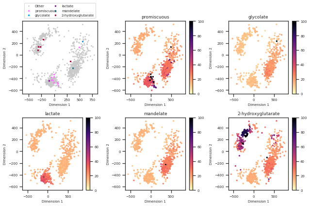

```python
fig = plt.figure(figsize=(9, 6))


# first plot the sequences that were active with the different substrates
plt.subplot(2, 3, 1)

background = count_result['Yes'] == 0
plt.scatter(my_plot[:,0][background], my_plot[:,1][background], s=small_point, color=other)

colors = [cluster3, cluster1, cluster2, cluster0, cluster4]

for i, subst in enumerate(substrates):

    if subst == 'promiscuous':
        act_w_subst = count_result['Yes'] >= 3

    elif subst == 'glycolate':
        act_w_subst = (props_and_experiments['glycolate'] == 'Yes') & (count_result['Yes'] == 1)

    elif subst == 'lactate':
        act_w_subst = (props_and_experiments['lactate'] == 'Yes') & (count_result['Yes'] == 1)

    elif subst == 'mandelate':
        act_w_subst = (props_and_experiments['mandelate'] == 'Yes') & (count_result['Yes'] == 1)

    elif subst == '2-hydroxyglutarate':
        act_w_subst = (props_and_experiments['2-hydroxyglutarate'] == 'Yes') & (count_result['Yes'] == 1)

    # plot the sequences active with that substrate
    plt.scatter(my_plot[:,0][act_w_subst], my_plot[:,1][act_w_subst],
                s=large_point,
                color=colors[i])

# add legend to plot
plt.legend(['Other'] + substrates,
           fontsize=font_size,
           loc='lower left',
           bbox_to_anchor=(0, 1.02, 1, 0.2),
           mode = 'expand',
           ncol=2)

plt.xlabel('Dimension 1', fontsize=font_size)
plt.ylabel('Dimension 2', fontsize=font_size)
plt.tick_params(labelsize=font_size)

# now make a plot each with the identity of all sequences compared to this
for i, subst in enumerate(substrates):

    ident_key = '%s_sim' % subst


    # make a plot
    font_size = 7
    plt.subplot(2, 3, i+2)

    sc = plt.scatter(my_plot[:,0], my_plot[:,1],
            s=5,
            c=props_and_experiments[ident_key].values,
            cmap='magma_r', # low contrast: 'viridis' 'plasma' high contrast: 'inferno' 'magma'
            vmin=0,
            vmax=100)

    plt.title(subst, fontsize=font_size+2)
    plt.xlabel('Dimension 1', fontsize=font_size)
    plt.ylabel('Dimension 2', fontsize=font_size)

    cb = fig.colorbar(sc)
    cb.ax.tick_params(labelsize=font_size)
    plt.tick_params(labelsize=font_size)

plt.tight_layout()


plt.savefig(join(FIGURES, 'figure4.png'), dpi=300, facecolor='w', edgecolor='w',
        orientation='portrait', papertype=None, format=None,
        transparent=False, bbox_inches=None, pad_inches=0.1,
        frameon=None, metadata=None)
```